# 2009年11月13日巴菲特与比尔盖茨对话哥伦比亚大学商学院的学生

**背景介绍**

每隔几年，巴菲特就和盖茨一起到美国的某所高校和学生们进行交流，主要目的是向青年学子灌输创新理念和投资理念，当然也和他们分享成功的人生智慧。2009年11月13日，巴菲特携盖茨回到了自己的母校——哥伦比亚大学，和在校研究生们座谈并回答他们提出的各种问题。鉴于当时美国金融危机愈演愈烈的形势，媒体给这次活动起了个振奋人心的名字，叫做“让美国继续保持伟大”（Keeping America Great）。

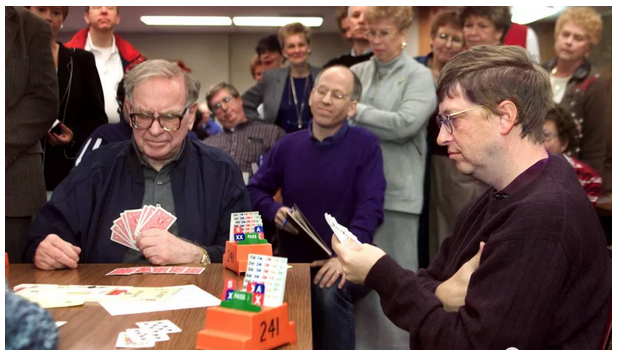

2004年，在奥马哈桥牌工作室举行的桥牌锦标赛开始前，沃伦·巴菲特和比尔·盖茨为媒体打了一手桥牌。

——JEFF BEIERMANN/《世界先驱报》

**播音员：**沃伦·巴菲特和比尔·盖茨是“美国梦”的具体践行者，他们靠个人奋斗而成为了亿万富翁，他们的价值观就像他们的财富一样深入人心。他们中的一个重新规划了一个产业，而另外一个则是现代投资大师。但他们都对美国充满信心，他们两人都积极投身于商业和人道主义活动，并收获这个伟大国度里的资本主义传统所给予的奖励。不过今天该传统正遭到冲击，我们的生活方式遭到了质疑。美国正处于转折期，一代年轻人希望从这两位世界上最了不起的资本家身上学习经验。今天他们两人返回校园，不是为了学习，而是为了传道，向未来一代的商业领袖说明财富不是你积聚的金钱数量，而是你影响的人数。今晚在CNBC主办的市政厅式讨论会上，沃伦·巴菲特和比尔·盖茨将同各位分享让美国继续保持伟大的秘诀。

**贝基·奎克：**欢迎各位参加一场由CNBC主办的特殊的市政厅式讨论会。我是贝基·奎克，我们现在是在哥伦比亚大学商学院。让我们听听你们的欢呼声吧，小伙子们。我们是在纽约的市中心。这里是世界资本集中的中心，这是一个真正让梦想成真的地方。事实上，此时此刻，看看今天来到这里的这些人吧。我们周围或许就是——未来的沃伦·巴菲特们和比尔.盖茨们。你们觉得怎么样？你们准备好了吗？

**学生：**我们今天来到这里感到无比激动。我们要是告诉你前排座位的票价是多少钱的话，你不会相信的。

**贝基：**我知道你说的不是真的。你们必须凭身份证才能进来，是吗？

**学生：**是的，这是真的。

**贝基：**今晚我们作好了准备。今晚的主题就是“让美国继续保持伟大”。

没人比沃伦·巴菲特和比尔·盖茨更适合阐述这一主题的了。朋友们，让我们欢迎沃伦。巴菲特和比尔·盖茨。

我发现沃伦正在试图调动哥伦比亚大学本地观众的情绪。

先生们，非常感谢你们今晚来到这里和我们在一起。众所周知，今年是不平凡的一年。在这一年里，规则被完全改写，我们把规则手册扔在了一边，而且看到偶像轰然倒塌。与此同时很多人在这段时间里也许在反思我们的生活方式，包括这个房间里的人们。1分钟后它将成为我们讨论的焦点。先生们，在我们正式进入主题之前，你们两位似乎看上去是非常怪的一对。在任何一个对你们两位不太熟的人看来……

**巴菲特：**等节目结束了你会觉得更奇怪。

**贝基：**是什么让你们两位今晚聚在了一起？为什么是你们两人，又为什么在这里和这些哥伦比亚商学院的学生们在一起？

**巴菲特：**嗯，我们喜欢在一起。实际上，当我离开哥伦比亚大学的时候，他们告诉我，我也许得回来复读一些课程。所以我来了。

**贝基：**比尔，你呢？你准备好和大学生们交流吗？

**比尔·盖茨：**准备好了，这将是很有趣的一件事。沃伦和我喜欢回答问题，喜欢谈论我们的乐观态度。

**贝基：**今晚之所以邀请你们两人来到这里，是因为美国正处于一个历史上的关键时期。人们对美国经济以及整个资本集中制度存在着很多疑问。先生们，让我问你们俩一个相同的问题，就是在过去一年里，是否有过那么一刻你曾经对资本集中制度以及我们的生活方式存在过质疑？

**巴菲特：**没有，任何时候我都没有怀疑过。如果真有那样的时刻，那该是去年9月份我们向经济注入大量资金的时候，当时美国似乎跌进了万丈深渊。资金从货币市场里的各种基金中流出。商业票据市场陷入绝境，诸如此类问题不一而足。我们投入了80亿美元，仅在几天后就见到了效果。所以我从来没有对经济制度失去信心。美国依然有效地运转着。我们有200年的历史为证。美国还将会继续有效地运转下去。

**贝基：**比尔，你怎么想？比尔？

**盖茨：**噢，我们拥有一个复杂的金融体系，事实已经证明我们这个体系会犯错误。但更为根本性的因素是创新，你可以创办新公司，人们愿意承担风险并进行投资，重大的科学发现不断涌现，这些都是事实。这个国家仍然拥有最好的大学、最厉害的科学，我们将对资本集中制度作出调整。我们用大量的短期贷款掩盖了长期需求，我们有大量的杠杆借贷，毫无疑问这些都是我们要吸取的教训。但美国资本集中制度的核心即市场化制度是会持续下去的，在这个制度下投资教育和诸多基础设施是为了长远打算。此外，我敢打赌，一些发明创新在去年秋天情况最为糟糕的时刻就开始进行了。人们研制新药物、新芯片、新机器人以及能够在未来数十年改善我们每个人的生活的新产品。

**贝基：**好了。今晚是由大学生们唱主角，我们何不马上让他们出场。你们在等什么？你们准备好了吗？

**学生：**当然。

**贝基：**那好。

**问题：**大家好，我名叫曼妮·佩雷兹，我来自新泽西州，是哥伦比亚大学大二学生。首先我想谢谢你们两位来到这里。我们感到非常荣幸你们能来到我们大学。盖茨先生和巴菲特先生，我的第一个问题是问你们两人的。对于贪婪和不道德行为到底是不是导致最近金融危机的原因，我想知道你们的观点。

**巴菲特：**最后一句漏掉了，贝基。

**贝基：**她想知道贪婪和腐败是不是幕后黑手。

**巴菲特：**它们当然起了一定的作用。我们永远都会有贪婪之心。贪婪并非过去这几年才出现的。贪婪与恐惧出现在了去年第三季度——我是说，那一阵子美国人民真的很恐慌。贪婪与恐惧影响到了他们的行为——它肇始于华尔街，但随后蔓延到了整个经济之中。但我们永远无法摆脱贪婪，我们永远无法消除恐惧。正如比尔所说，我们拥有的是一个市场制度，在这个制度下人们拥有均等的机会和法治，在过去200多年里两者共同释放出来的美国民众的潜能之大是几百年前的任何人都想象不到的。

这个制度没有任何错。我们的经济像一台出了故障的机器一样吱吱作响，现在还在吱吱作响。但我们为这台机器安装了最棒的引擎。好戏刚刚开始。贪婪还会延续。不用对此忧心忡忡。奥利弗·斯通即将完成《华尔街》的续集。也许值得一提的是在这部电影中戈登·盖柯重返华尔街。但那并不是推动美国制度进步的因素。推动美国制度进步的是人们在市场制度中获得的平等机遇以及你在这里获得的知识，当你离开这里之后就能享受由它所带来的成果。这将继续推动美国前行。我愿意和你们中的任何一个人交换位置。

**贝基：**比尔，你在这个问题上还有什么其他的想法？

**盖茨：**噢，最好的制度是这样一种制度，你拥有不错的短期测评标准、有完善的会计制度、你追逐利润但同时也关注风险并愿意着眼于长期目标、投资于新研究、让人们创办新公司。美国在鼓励年轻人冒险方面举世无双，而我就是最大的受益者。你知道吗，我必须招募那些年龄较大的人。我必须将产品销售给较年长的人。这就是所谓的梦想成真——其他国家目睹了这一切，他们正努力创造同样的活力。这有利于全世界。中国和印度将借鉴我们关于大学教育、创业精神以及简化商业流程的理念，这很不错。我们谁也不想再重蹈我们过度杠杆借贷的覆辙。不过在某种意义上说，那有点——我不想贬低它，但它不是美国制度运转如此之良好的根本原因。

**贝基：**好吧。让我们看看下一个问题。这里有人要问吗？

**问题：**你们好。我是阿克莎·白吉玛，来自北弗吉尼亚地区，我是哥伦比亚大学大一学生。我想再一次感谢你们两位的到来。这是我们的荣幸。我问盖茨先生一个问题。盖茨先生，我知道你不是搞金融的，但你能告诉我们，当你第一次听说雷曼申请破产保护的时候你是怎么想的吗？

**盖茨：**我不大关注投资银行。因此，雷曼申请破产保护并没有让我觉得是一件多么可怕的事情。在科技行业，我最景仰的两个公司王安电脑公司和数据设备公司实际上都基本破产了。数据设备公司实际上被收购了。因此事实是，市况总有起有落，某些公司被淘汰出局，我并不会对哪家公司出局感到失落。但倒闭带来的连锁反应影响到了那些相关债权人，那些人将会惴惴不安，这就让局面变得复杂化了，而这种复杂性可能会导致市场冻结，我当时给巴菲特打电话说：“我应该对此感到担忧吗？”他回答说：“该有一点吧。”

**贝基：**沃伦，政府放任雷曼兄弟破产是个错误吗？

**巴菲特：**或许是吧。我想说的是，正如我们此前讨论过的一样，总的来说华盛顿的官员在应对这场所谓的经济领域“珍珠港事件”时表现得相当不错。所以我想说假如当时美国银行没有收购美林的话，美林很快就会消失掉了。当时一串多米诺骨牌确实排在了那里。我觉得政府可能没有完全认识到雷曼兄弟是一张多么庞大的多米诺骨牌，或者没有意识到它会对其他大型的多米诺骨牌造成怎样的影响。但总的来说，我对（美国前财政部长）保尔森、（美国联邦储备委员会主席）伯南克、（美国联邦存款保险公司主席）谢拉·贝尔、（现任财政部长）蒂姆·盖特纳给予很高的评价，因为他们面对危机采取了史无前例的举措。

**贝基：**让我们听听下一个问题。在麦克风后面的那位同学。请提问。

**问题：**我希望这个麦克风能用。

**贝基：**能用。听上去没问题。

**问题：**大家好，我名叫格莱格·特。我在俄亥俄州长大，很明显我也是这里的一名大学生。我问一个关于雷曼兄弟以及高盛银行的问题，这个问题和巴菲特先生有关。巴菲特先生，你曾有机会对它们进行投资，我想问的是你是如何选择投资高盛银行的？你为什么没有对两家银行都投资呢？换言之，是什么让你决定不对雷曼兄弟进行投资？

**巴菲特：**那个时候，相对于华尔街任何其他公司而言我对高盛银行的财务数字以及管理层更有信心。现在看起来，当时有可能会发生一些事让高盛成为倒下的另外一张多米诺骨牌。（高盛总裁）罗伊·布兰科菲恩曾经说过，他在摩根·史坦利倒掉后的工作时间为30秒钟。安德鲁.罗斯·苏尔钦在他的《老大不能死》这本书里很好地讲到了这一点。但我不认为我们的制度会随之崩溃。我认为华盛顿最终会采取正确举措。我认为，如果华盛顿采取正确举措，高盛就是我认为它就是我的最佳选择。我认为高盛的财务数据最为健全，我认为它们的前景最为光明。另外，我也喜欢那些投资条款。

**贝基：**沃伦，你那时说高盛拥有最好的管理人员和很多其他优点。从那以后你改变过看法吗？

**巴菲特：**请再说一遍，好吗？

**贝基：**从那以后你改变过看法吗？你说过他们的管理层最好。

**巴菲特：**我和高盛的交往史可以追溯到1940年我遇见西德尼·温伯格。我追踪这家公司很长一段时间了。他们拥有严格的纪律，尤其是他们对市场的时机把握能力，我认为可能是华尔街所有公司中最为出色的。我认为罗伊·布兰科菲恩有着很强的风险判断力。如果金融体系崩溃，那么所有人都会受到冲击。但我觉得高盛在很大程度上拥有业界最优秀的人才。因此，高盛是我的首选。当时人们也给我了一些其他选择方案。

**贝基：**大家提下一个问题。下一个问题。

**问题：**今天很高兴和你们两位在一起。我叫约翰·莱姆利。我来自纽约的斯卡斯代尔镇。考虑到经济衰退的严重性，一些人将此归咎于对于风险监管和贷款担保标准监管的系统失灵，随后党派之间就政府应当扮演怎样的角色这一问题展开了激烈的争论。政府能够在其中扮演积极角色吗？如果能的话，它如何扮演？

**贝基：**你们两位怎么看待大政府？

**盖茨：**显然政府在经济周期中发挥着作用。随着时间的推移，政府的角色也在进行微调，错误也时有发生。问题是——它所犯之错主要是通过通货膨胀和利率水平进行衡量。现在的问题是——是否存在一种风险衡量方法，使政府干预经济——或许开征交易税，让较大型的公司把更多的资金闲置起来。所以切实的问题依然是——你是否能认识到这些情况并让政府发挥积极的作用。当事情开始变得不可收拾的时候，我们知道政府能够更为迅速地采取一些举措救助那些正在走下坡路的公司——在这方面政府大有可为。但一个基本思想是，你能够发现泡沫吗？政府能发现泡沫吗？这是一个大问题。一些伟大的经济学家对此有一些看法。但这是个未知领域。

**巴菲特：**去年9月，只有政府才能挽救局面。整个世界都想减持债务。人们争相减持债务，几乎到了慌不择路的程度，有的人则被逼无奈而减持。就在人人都想减持债务的同时，唯一可能增持债务的实体就是联邦政府。就在2000亿美元数日之内撤出货币市场里的各种基金之时，就在商业票据市场停止运转之时，只有联邦政府才能采取行动。幸运的是我们联邦政府官员认识到了这一点，迅速采取了行动。政府发挥着巨大的作用。放眼未来，要想出一个办法来制止过度借贷并阻止资产负债表外的交易陷入困境或者不让大型风险机构的高管们去冒险，这将是非常困难的一件事。但我们正在全力应对。任何以建设更强的社会为借口而不得不向联邦政府寻求救助的金融机构高管都应当受到更多的惩罚。目前为止，在对那些CEO们采取胡萝卜加大棒的激励措施方面，我们已经有所改善。但我觉得政府还应该使出更多的“大棒”。

**贝基：**好的。让我们看看下一个问题是什么。

**问题：**我是哥伦比亚大学大一的学生，名叫布莱恩。我现在一所商学院学习，在我看来在这次全国性的信用危机中，商学院的毕业生扮演了极为不光彩的角色。你们两位认为，像哥伦比亚这样的商学院在多大程度上应当为信贷危机所发生的一切承担起一定的责任呢？

**盖茨：**记住，资本集中制度取得了巨大的成功。人们的生活水平、医药等一切重大的事物都来自于这种制度。商学院的职责之一就是训练人们思考什么是价值和领导力。伟大的商学院如哥伦比亚大学商学院会教授学生们出色的技能。现实是，没错，我们遭遇了一场危机，我们遭遇了挫折，或许我们因为犯下的错误而白白浪费了两到三年时间，但这并不是说商学院就不会发挥重要的作用。未来几十年，这里的商学院都会教授此次危机中出现的个案研究。至少我们会“吃一堑长一智”吧。

杠杆借贷是一件非常危险的事。巴菲特也许说过了，金融衍生品就好像大规模杀伤性武器样。但它没有引起足够的重视，结果最后出了问题，特别是在房地产领域，人们不太明白房价下跌所带来的风险及其对那些衍生品工具带来的系统性风险。大规模破坏随后如期而至。

**贝基：**沃伦，你能在商学院里教授道德课程吗？它必须来自别的什么地方吗？

**巴菲特：**你是说我现在回来教书？

**贝基：**你能在商学院里教授道德课程吗？

**巴菲特：**噢，我觉得学习道德的最佳场所就是在家里。我认为我们大多数人在上商学院之前就从我们看到的周围事物上学到了价值观。我认为重要的是强化那些道德观，但我觉得，如果你让我选择是在家里还是在学校里接受良好的教育和道德观的话，我会选择在家里。奇妙的是，在这个国家有德之人会取得巨大成功。道德不是绊脚石。它有时是助推器。有时它又是不偏不倚的。不过它绝对不是绊脚石。

简言之，这里的每个人都会有一个不错的未来。我是说，你们将要进入的是一个充满活力的经济体。如果你回顾19世纪，我们曾经有过7次银行大恐慌事件。如果你回顾20世纪，我们有过大萧条、世界大战和大流感。美国并不能避免出问题。但它可以解决问题。在未来100年里，我们的制度这台“机器”还会出故障而吱吱作响。或许未来15年都是平平凡凡的岁月，但我们还有85年的时间。在20世纪，道琼斯指数从66点上升到11400点，所以这是一片肥沃的土地供你耕耘，我们没有理由投机取巧。

**贝基：**好吧。让我们听听下一个问题。

**问题：**你们好。我的名字是卡特里娜·甘可娜，我出生在俄罗斯。现在我是哥伦比亚大学商学院的研二学生。我的问题是针对盖茨先生的。你觉得哪个行业最有可能产生下一个比尔·盖茨？因为我本人就想投身于那样的行业。

**盖茨：**每个行业的技术创新步伐并不相同。IT行业因为有了魔幻般的软件、光纤及芯片——每隔几年其速度增加一倍——而一直成为一个不但最令人激动而且也改变了其他很多行业规则的行业。现有的信息量有多大、网上的世界是个什么样子，这些都让人难以相信。我想告诉你们的是，今后数十年内有一些行业将会和IT行业一样地让人激动。能源产业将提供更加廉价且环境友好的能源。该产业里存在着大量的科学技术，存在着大量的生意。那是全球性的行业。该行业将提供一些非常不错的职位。另一个是医药行业。我们还无法治愈帕金森症、阿尔茨海默症，我们也没解决那些贫穷国家里的20多种疾病，但我们可以确信的是我们正沿着正确的道路前进。因此，我认为你们会在这三个行业里大显身手。还有很多其他的行业，不过这三大产业对我本人的吸引力最大。

**巴菲特：**找到让你最兴奋的、最能激发你工作热情的行业。当年我离开哥伦比亚大学的时候，假如有人告诉我比尔所在的行业将会是一个令人激动的行业的话，我并不认为自己能够在那个产业内做得如此之好。但我知道如何寻找自己感兴趣的领域。本·格雷厄姆教授曾是我的老师。我曾请求为他免费工作。他说：“你高估了自己的身价。”但无论如何，我还是入了行。我敢保证，无论你干什么，只要你感兴趣，你就能做得很好。对于这一点各位不用怀疑。不要让别人告诉你该做什么。想想自已在干什么。

**贝基：**好的。事实上我们得到了一次对这些学生们进行调查的机会。我们问他们，在一生中会不会遇到像微软这样具有变革能力的公司。你可能对他们的回答感到惊讶。我们休息一会之后马上告诉你。

**贝基：**欢迎大家回来继续收看由CNBC主办的市政厅式讨论会。我们现在是在哥伦比亚大学的商学院，和我们在一起的是比尔·盖茨和沃伦·巴菲特。我们是在纽约的市中心。在我们休息之前，我们问了一名学生一个问题——实际上是一名学生问了这样一个问题，即哪个行业将会产生下一个比尔·盖茨。

正如刚才我们说过的，我们对这个房间里的学生们作了一个调查，我们问他们在有生之年能否再看到一家同微软一样具有创新精神的公司？先生们，10个学生里有8个学生说“能”。也就是说80%的受调查者给出了肯定答案，他们的确认为这将是另外一个问题。你们真是一群非常乐观的人啊。比尔，你认同他们的这种乐观态度吗？

**盖茨：**绝对认同。资本集中制度是优良的制度，它催生了大量的新生事物。虽然其中有很多会归于失败。一些表现平平。但另外一些则卓尔不群，它们能够不断成长并让所有人都惊叹不已。在我前面提及的所有产业中都将会出现一些让人惊叹不已的公司。

**贝基：**好的。我们看看下一位同学提什么问题。

**问题：**大家好，我叫丽萨·威廉姆斯。我来自新泽西的南奥兰治。我现在是一年级MBA研究生。很高兴见到你们两位。我实际上想问巴菲特先生一个问题。有关伯林顿北方公司交易的真实动机人们众说纷纭。我很想知道你能否告诉我们，你此时增持铁路部门股票的主要动机是什么？

**巴菲特：**你知道吗？在刚满6岁的时候，我特别渴望能得到一整套火车玩具，但老爸没有给我买。你们想想看吧。铁路同美国未来的繁荣发展息息相关。你无法把这里的铁路搬到中国、印度或任何别的国家去。我们从这个前提出发，而且我认为这是个最基本的前提，美国人口在今后10年、20年、30年内将会增加。越来越多的物品在他们之间来回流动。而铁路运输是你邮寄物品最环境友好、最合算的途径。伯林顿北方公司去年平均每加仑柴油运输一吨货物达470英里。该运输方式的成本远远低于高速公路。

整体来看，火车消耗的燃料比卡车少三分之一，污染物排放量也低于卡车。一列火车的运输量大约相当于280辆卡车的总运输量。因此铁路更符合未来的运输需求。我喜欢美国西部地区。我喜欢伯林顿公司拥有的数万英里铁路线。你知道吗？如果美国前景不妙，那么铁路的前景也就很暗淡。我愿意下赌注——具体来说赌金是340亿美元——赌今后10年、20年及50年内将会有越来越多的物品是通过铁路来运输的，这更加有利于美国，也更加有利于伯林顿公司的股东。

**贝基：**好。下一个问题。

**问题：**大家好。我的名字是乔什·波特。我是来自马萨诸塞州北雷丁镇的大一学生。我们刚刚经历过但愿是我们一生见过的最为严重的金融危机。我知道它让很多美国人寝食难安，为自己的前途而担心。是什么事情让你们两人都寝食难安呢，假如有那种事情的话？

**巴菲特：**我努力热爱自己的生命，因此没有什么事情让我寝食难安的。你知道吗？我不想让自己听上去像是流行病爆发季节里的殡仪师，但去年秋季发生的事确实让我很激动。虽然我并不希望那样的事发生在任何人身上，但它确实发生了。一两年前不存在的机会现在出现在了我们眼前。因此我真的没有——我并不想让自己处于一种负债累累或彻夜难眠的境地。我并不担心我们经济制度会最终消亡。我们陷入了混乱，这一点毫无疑问。但工厂没有消失。玉米地也还在。美国人的聪明才智并没有消失。下一个比尔·盖茨的创新精神并没有消失。美国会好起来的。我心知肚明。我们需要做的就是拨乱反正。我们已经在这样做。

**贝基：**盖茨，你刚才提到——你刚才提到曾给巴菲特打电话，他的回答是：“是，我们也许应该有那么一点点担心。”那晚上你是否因为担心而彻夜难眠呢？

**盖茨：**没有。幸运的是，美国金融体系因有一批优秀的管理人才而具备自我调节能力。我认为有些具有负面影响的事件会让我们大吃一惊。在今后20年里恐怖分子有时会制造大型的恐怖事件，那会造成相当大的负面影响。流行病也是如此，目前正爆发的新型流感按照其传播速度实际上就是流行病。幸运的是，这次流行病的实际影响不是很大，远不及前几次。所以你必须随时关注这些异常情况。这是我想指出来其中两件异常事件。但整个体系的其余部分则具备超强的自我纠正能力。从长远看，一件不让我彻夜难眠但却让我忧心忡忡的事情就是我们的教育制度——特别是贯穿幼儿园到12年级的教育制度——并没有得到应有的改善。教育制度对于人们获得机会而言非常重要，对于美国经济增长而言非常重要，既然美国教育制度还没有得到很大的改进，它就有点让人担忧，因此需要更加引起我们的注意。

**巴菲特：**贝基，如果你拥有一家不错的农场，而且你知道今后50年内将会出现5次旱灾，但其他年份皆风调雨顺，我是说你该不会因为一想到那5年的旱灾而崩溃瓦解吧。你会认为你拥有一个随着时间流逝而运转良好的系统，那就是我们美国的经济系统。

**贝基：**我们刚刚碰到了一个旱灾年，那会不会让它不大可能——

**巴菲特：**不会的。如果你在哥伦比亚大学学习统计学的话，你会认识到——

**贝基：**好的。让我们看看下一个问题是什么。就在后面的这位学生。

**问题：**我叫皮特·劳伦斯，是哥伦比亚大学的大一学生。首先非常感谢你们两位来到这里。巴菲特先生，近来市场出现了历史性的扩张。但很多人似乎对当前股价水平的可持续性怀有疑问。你觉得这种回升是真实的吗？

**巴菲特：**谁知道明天会发生什么事情？我来举个例子。1942年，我买入了自己的第一支股票。那年我11岁。此前我一直磨磨蹭蹭没有买。到了11岁的时候我才认真起来。你认为自1942年以来一直到现在哪年股市表现最好？就是从1942年以来一直到现在最好的一年。嗯，你们没理由知道答案的。答案是1954年。1954年的道琼斯上涨了50%。现在如果你回头看一下1954年，就会发现当年我们大部分时间也是处在经济衰退时期。那次经济衰退始于1953年7月。美国失业率于1954年9月达到了最高点。一直到1954年11月就业数据才有所好转。在那段时间里失业率翻了一番多。但那一年却是股市表现最好的一年。由此可见，基于当前经济状况来决定是否购买或出售股票是一种糟糕的错误做法。你应该依据你的投资回报率，即在任何时候你购买股票的长期价值来决定是否买入或卖出股票。

“下周”本身没有什么意义，因为下周离现在还有一周的时间。重要的是要有远见，要对投资对象作出评估。如此一来，糟糕的市场或糟糕的经济就是你的好朋友。我在购买伯林顿公司时根本不去考虑运输业是否会在下周或下个月甚或明年出现重大转机或诸如此类的事情。像这样的时期给了我出手的机会。坐等是愚蠢的做法。我曾写过一篇文章，我说等你看到知更鸟时，春天已经过去了。

**贝基：**但与此同时——沃伦，去年你曾多次说过，在美国不少领域里的投资其实是在赌美国的未来。可是你还在海外市场进行投资，比如你投资中国的比亚迪公司。你们两位都去过中国。海外机会多还是美国机会多？

**巴菲特：**我觉得美国机会更多。我们是全球规模最大的经济体，我们正在这里寻找大买卖。但我也很高兴能够在其他地方寻找投资机会，无论是在中国或者以色列，比如我们对伊斯卡公司的投资等等。美国的投资机遇多于其他任何地方。

**贝基：**比尔，你同意巴菲特的这个观点吗？

**盖茨：**嗯，同意。全球得益，美国也就得益。你找不到这样的一个案例，即世界上其他地方表现都很差，而唯独美国表现很好。我们的命运同自由贸易以及无处不在的技术创新紧密连接在了一起。你知道吗？甚至伯林顿公司所使用的一些铁路设备很可能就是来自其他国家。

**巴菲特：**我希望如此。

**盖茨：**看到中国发生的事情令人激动。那对我们而言是相当好的一件事。如果我们可以替所有中国人作出选择，是让他们过和我们一样富裕的生活，还是让他们回到1979年去过过去的穷日子的话，那么让他们也成为像我们一样的消费者和发明家则会大大地改善我们的境况。虽然中国离这个目标还有很长的道路要走，但中国人口数量庞大，而且那里正在发生可喜的变化。众所周知，过去那些被我们视为不能自理需要接受我们大量援助的国家，如巴西、墨西哥和泰国，现在都成为了全球经济的重要贡献者。所以世界不再仅仅依赖于美国，这是件好事。而且美国很可能是能源革命仍将发生、IT革命仍将继续的地方。人们寄希望于我们在这些领域扮演领导者角色。

**贝基：**好的。我们很快回来继续下一个问题。顺便问一句，如果你有机会的话，你如何打算让沃伦·巴菲特和比尔·盖茨作为你的职业规划师帮你出谋划策？好，我们回来时将回答这一问题。

**贝基：**欢迎大家回来。我们有更多的问题要问比尔·盖茨和沃伦·巴菲特。我们穿越在学生们中间，但让我们继续鼓励他们提问。就在这里有人要提问。

**问题：**我的名字是艾丽卡·布莱丽，我是一名大二的学生。我想问盖茨先生一个问题。你每天做的最重要的事情是什么？

**盖茨：**嗯。哦，我每天做很多事情。我认为大量读书和继续学习最重要。我在基金会里遇到大量我并不熟悉的领域，如教育和卫生。我喜欢大量阅读。所以我想，用那些知识武装自己头脑，然后和那些有经验的人坐在一起交流并和他们来一场头脑风暴，这些会帮助我支持那些合适的人选并确保我了解实际发生的情况。因此我想说，学习是关键。

**贝基：**让我们听听下一个问题。

**问题：**巴菲特先生，盖茨先生，谢谢你们今天大驾光临。我叫贾斯汀.海曼。我是MBA研二学生，因为我马上要毕业了嘛，所以我想问，当你们离开这里踏进社会后，你们的MBA课程没有教会你们的一件事是什么？

**巴菲特：** 哦，我当时——它让我作好了充分的准备，我不是说我的学位让我作好了充分的准备，而是那些教授们让我作好了充分的准备去进入我想进入的领域。就像我说的一样，我在六七岁的时候就知道自己对投资感兴趣。所以幸运的是我很早就找到了自己感兴趣的东西。在哥伦比亚大学我遇上了两位了不起的教授——我读遍了他们写的文章。所以我获得的不是增量知识，我获得的是灵感。那两位教授待我很好，待我就像对待他们的儿子一样。他们还经常带我出去吃晚饭。本·格雷厄姆也是这样待我的。所以MBA课程给了我自信心。它把我带入了一个我本人已经非常喜欢的领域，而在这个领域里我搭上了那些对我充满信任的教授们的超棒顺风车。

不过请允许我补充一点——是关于MBA教育处境的。现在，我愿意出10万美元来换取在座任何一个人未来10%的收入。任何想要这10万美元的人在节目结束后都可来找我。如果这个交易条件成立的话，你现在的身家就是100万美元，对吧？假如你的10%的收入是10万。你们可以提高自己——你们中的很多人都可以，当年我离开学校的时候当然也是可以提高自己的，只要学会沟通技巧就可以了。你知道吗？沟通技巧可不是在课堂上学到的东西。实际上我后来去听戴尔·卡耐基的公开演讲课。可是如果你们通过提高沟通技巧使你们的价值增长50%，则你们的资本价值等于升值了50万美元。下课后来找我，我将支付你15万美元。

**贝基：**沃伦，你把你的快乐时光带到了这里。我不知道你是否看到了后面的显示器，但我们确实看了一眼你的年鉴并偷了一张你1951年的照片。

**巴菲特：**喔，糟糕。

**贝基：**我想我们在背面有一张照片。就是这张。

**巴菲特：**我不认为我愿意出10万美元买那个家伙的10%的未来身家。

**贝基：**这里有人提下一个问题。

**问题：**你们好。我叫奥列格·切什。我是这里的MBA研二学生。我想请盖茨先生回答我的问题。你显然是通过自身艰苦努力而取得了今天的成就。你能回顾一下纯粹的幸运在你成功之路上扮演什么样的角色吗？

**盖茨：**是，我在很多方面都非常幸运。我幸运是因为我生来就有某些天赋。我幸运我父母给我创造了一个可以分享他们的工作成果并让我购买任何自己想看的书的环境。我幸运自己赶上了好时候。当时微处理器的发明意义深远。事实证明只有关注它的年轻人才懂得欣赏该发明所带来的东西。随后我对编写软件上了瘾。事实证明软件是能使处理器产生不可思议影响的关键因素，而当时软件奇缺。我非常幸运地赶上了好时候并且拥有一门编程技术，我非常幸运地遇到了一些人，我遇到了巴菲特，我和他交谈，向他学习，我想一个人在一生中很难碰到这么多幸运事。但幸运正是我能做这些事情的主要因素。

**贝基：**好的。这里有人问下一个问题。

**问题：**你们好，我名叫尤金·奎恩，来自伊利诺伊州的迪尔菲尔德市，是哥伦比亚大学商学院的一年级学生。我想请巴菲特先生和盖茨先生同时回答我的问题。鉴于你们的工作关系和独特的个人友谊，你们最欣赏对方哪一点？

**贝基：**好。谁先说？

**巴菲特：**我的体育运动能力。可以这么说吧。嗯，我想说的是，我真正最佩服盖茨的是他处理自己积累起来的财富的态度。我是指，就像他所说的那样，他确实很幸运。他在合适的时间生在了一个合适的国家，而且身怀合适的技术，如此等等。他最终懂得他是这个很棒社会的宠儿，并非每个人都会像他或我那样得到一个“长吸管”。因此他就是——他认为世人皆平等，于是他不仅利用金钱来支持自己的这一观点，他还拿出自己的时间来践行这一理念。他妻子梅琳达也拿出时间支持他的这一观点。他们真的将拿出自己差不多后半生的时间把财富、才华、精力、想象力等用在改善全球65亿人生活质量的事业之中去。这是我最钦佩他的地方。

**贝基：**比尔？

**盖茨：**沃伦身上有许多优点可以挑出来作为我最佩服他的答案，比如他的真诚就为世人树立了榜样，还有他的幽默感。但我想我会挑选他诲人不倦的愿望，他愿意深入浅出地教导他人，如此一来，人们就能恍然大悟并从他的经验以及他对世界运行规律的看法中得到教益。他乐于教导他人。他和学生们见面时是这么做的。他在每年给股东写信时是这么做的。他在给我打电话时是这么做的。这是真正的天赋，让我无比佩服。

**贝基：**让我们听听这一位提什么问题。

**问题：**巴菲特先生，盖茨先生，感谢你们今晚光临此地。我是易卜拉欣·多利，是哥伦比亚大学一年级学生。我来自葡萄牙。我想问你们两位一个问题。在你们的职业生涯中，你们很早便知道自己想要做什么。对于我们这些还懵懵懂懂的人，你们有什么建议吗？

**盖茨：**哦，要找到激发你热情而且你又擅长的事情，有时候可能得花上若干年时间。我想沃伦和我都挺幸运的，我们都有点撞大运的意思。那时候我甚至不知道我的兴趣就是软件。我对它有点痴迷，但还不清楚编程会成为我的职业。当那事发生的时候，我感觉真好。我想大部分人到20多岁的时候就不得不尝试一些不同的经历了。有些事情会为你提供很多不同的生意机会，或者为你提供很多不同的工作机会。我想你可以从最初的几份工作中挖掘这样的机会。然后当你发现你为之疯狂的事情之后，就开始干吧。

**贝基：**好的。

**巴菲特：**第一，我想说的是，找个合适的人结婚吧。我是认真说的。婚姻将让你的生活变得更加不同。它会改变你的抱负等等。非常重要的一点是你跟谁结婚。除此之外，我想说的是，如果你处在我的位置上，钱财对你而言已经没有什么意义，那么就做你喜欢做的任何事情。我今年79岁了，我每天还上班。这才是我最想做的事情。你越早离我所说的这个目标越近，你在生活中获得的乐趣就越多，你的工作也就会做得越好。所以不要被眼前的蝇头小利所驱使。此外如有可能，要为你钦佩的组织或个人去工作。我指的是，我主动提出为本·格雷厄姆工作，因为他是业界我最为钦佩的人。我根本不在乎他给我多少报酬。他最终于1954年雇用了我，我就从奥马哈市搬到了纽约，在我得到自己的第一张工资单之前我根本不知道自己的薪水是多少。但我知道我愿意为本·格雷厄姆工作。我知道自己每天早晨会从床上一跃而起，对我要做的工作充满期待，等到我晚上回家时，我又变得比早晨聪明了一些。去找一份你感兴趣的工作，为能够激起你工作热情的个人或机构工作。

**贝基：**请不要走开。我们一会就回来。

**贝基：**好的。我们继续“上课”。我们回来听听由这两位最杰出的资本家给我们带来的“101堂投资课”，回来听听同学们提出更多的问题。我们何不从这里开始呢？

**问题：**我的名字是亚当·冯·戴姆，是这里的一年级学生。这个问题请巴菲特先生回答。如果说收购伯林顿北方公司代表了你的“长期投资永久持有”的投资理念的话，我想知道本次金融危机是否对你的投资理念或投资过程产生了影响？

**巴菲特：**没有。这次金融危机对我的投资理念没有产生任何影响。我们喜欢这样的产品。金融危机如何对这种无耻的商品产生影响呢？这种商品始于1886年。它经历过所有的风风雨雨。结果今天一天8盎司瓶装可口可乐的消耗量将是16亿瓶，到明年这个数量还将会增加。我们想进入这样的企业，该企业拥有持久的竞争优势，拥有我们喜欢并相信的管理层，然后我们以我们喜欢的价位购买其股票。我们的投资理念丝毫没变。附带说一句，我们也拥有鲜果布衣公司的股票，但我不打算生产产品。

**贝基：**好的。我们的下一个问题来自这里。

**问题：**你们好，我是布莱恩·赛达巴克，是二年级学生。巴菲特先生，再次看到你我感到很高兴。上个月我去了趟奥马哈。感谢你招待了我们。我的问题是，对于今天遵循格雷厄姆和多德的投资哲学去配置资金的个人投资者来说，你会有什么样的建议？

**巴菲特：**噢，这将取决于他们是否是主动的投资者。格雷厄姆将投资者分为防御型和进取型两类。所以如果你愿意在投资上花大量时间，我建议你尽可能多地阅读些材料，这样你就会找到一些便宜货。如果你发现了目标，你就得赶快行动。这个原则没有——自我于1950年、1951年来到这里后就一直没变过。我今后也不会改变它。

你开始翻书。在我离开学校后，我把厚达1万页左右的穆迪投资报告中的每页都看了两遍，目的是寻找合适的公司。你得自己去寻找。世人不会告诉你哪儿存在好买卖。你得自己去寻找。而这需要耗费你大量时间。所以如果你不打算那么做，如果你只想成为一名被动的投资者，那么我只能建议你长期持有指数基金。

我要告诉你的是，人们最糟糕的投资方式就是持有现金。人人都在谈论“现金为王”之类的话题。但对于你们绝大多数人而言，你们看上去并没有被身上的现金压弯了腰。随着时间的推移，现金将贬值，但好公司则将会升值。你并不想在它们身上付出太多，因此你务必立下一些规矩。你需要做的就是找到一家好企业并坚持和它站在一起。

**贝基：**这是否意味着你认为我们已经度过了最困难的时期？你以前也经常说要持有现金。

**巴菲特：**我们一直持有足够的现金，所以我才感到非常的舒服，晚上睡觉也不用担心。但我这样做并不是因为我把持有现金当做了一种投资工具。长期来说，持有现金是糟糕的投资方式。但你总想拥有足够现金，这样才能避免由别人来主宰你的未来。最糟糕的——金融恐慌已经过去。但某种程度上由金融恐慌所导致的经济动荡还没有完全消失。它会结束的。我不知道它结束的时间是明天、下周还是下月，或许是明年。但它不会永远持续下去。人们在今年3月份试图抄底，但美国失业率仍未触底，美国商业活动也未触底，而股市已经触底。不要因为觉得明天会找到比今天更加有吸引力的东西而拒绝今天有吸引力的东西。

**贝基：**这里有人提下一个问题。

**问题：**巴菲特先生和盖茨先生，我的名字是安托瓦内特·吉纳维。我是EMBA一年级学生。我实际上在高盛工作，所以谢谢你们投资于高盛。

**巴菲特：**你为什么不在班上？

**问题：**我的问题是，想请你们两人谈谈在投资可替代能源以促进经济发展并让经济重新回到正常轨道问题上的想法。

**贝基：**比尔，你较早前接触过这个问题。

**盖茨：**哦，人们在这个问题上有很多很多的想法。可以这么说吧，其中大部分想法将被证明是死路一条。太阳热能、太阳电能以及核能都将得以复兴，但它们需要解决高成本带来的挑战。

我们希望美国能够确保所有这些替代能源都得到足够的研发经费和监管，因为其中一种能源将会为我们提供安全廉价得多但又不会带来任何问题的动力。我们不知道具体是哪一个。我们对这些替代能源的研发投资力度还不如我预期的大。我们有了不小的进步，但我认为政府的政策能够鼓励更多的投资。不过替代能源实际上是目前的热门投资领域之一。

当大家都关注一个领域时，就会有大量资金涌入该领域。总体资本回报率也会很高。美国汽车业在其鼎盛时期变成了一场灾难。航空业甚至软件业也是如此，因为人们直到今天才记得非微软的软件是存在的。当某种东西成为抢手货时，泡沫就会出现。因此，应该谨慎对待替代能源，确保替代能源的成本结构是合理的，而不仅仅靠政府补贴向前推进，确保科学奇迹在未来出现。因此替代能源是一个热门投资领域，但未必是一个好的投资领域。

**贝基：**好的。我们何不休息一会呢？当我们回来时，我们将和比尔·盖茨和沃伦·巴菲特讨论更多的问题。我们回来后将谈论领导力和奥巴马总统。

**贝基：**好的。欢迎回到我们的节目来。我们是在哥伦比亚大学。现在我们直接来到哥伦比亚大学商学院高层的身边。这位是哈伯德院长。顺便提一下，格伦·哈伯德不仅仅是商学院的头，他还曾在白宫任职过，他曾经担任经济顾问委员会主席。所以这个人不仅仅对经济的运行了如指掌，他还对这些学生们的言行了如指掌。你一直和他们交谈。你想问盖茨先生和巴菲特先生什么问题？

**哈伯德：**谢谢你，贝基，也感谢你们两位今天来到这里。沃伦，欢迎回家。

**巴菲特：**谢谢你。

**哈伯德：**沃伦，几年前你说过一句话，这句话一直萦绕在我心头，你说除非潮水退去，否则你永远不知道谁在裸泳。那当然说的也许是知道何时会退潮的重要性。它同时也指明了洞察环境的重要性。我们该如何培养——我们如何鼓励商业领袖洞察环境并将点点滴滴勾连起来？

**巴菲特：**哦，我觉得他们在过去一年里学到了很多东西。你知道吗？有些人从来不学习。在伯克希尔，我们实际上有70名左右的经理。我认为，他们大多数人都比15个月前更为聪明了。

不过，他们加入我们企业本身就说明他们足够聪明。但你知道吗？我认为我是从本·格雷厄姆那里学到了经验教训，他过去每周四下午来这里上课。你知道吗？他不需要那么做的。他把挣到的所有钱都捐给了这所学校。拥有合理的原则能让你渡过一切。我从格雷厄姆和多德那里学到了一些基本原则，我对这些原则没必要作任何改动。它们引领我度过了美好时光。它们也引领我度过了艰难时光。最终我不需要对它们感到担忧，因为我知道它们有效。

**贝基：**比尔，你认为一名商界领袖最重要的特质是什么？

**盖茨：**哦，令人惊讶的是，经商的基本要素非常简单。你试图让获得的收入高于你所花的成本。这是一道非常简单的减法运算题。但同样令人惊讶的是，你要提前几年就要作出如下这样的规划：我们是否进行正确的投资？我们是否能在竞争中胜出？我们做的事情别人是否难于替代？这是常识，但我想你需要通过历练才能体会这些常识。我认为理想的情况是，如果你年轻，你就可以从小打小闹中获取这些常识并亲身实践它们，因为很多从一开始就做大生意的人可能很难获得这样的常识。所以基本原则是很简单的。通过阅读大量书籍学习这些原则在各类行业里是如何起作用和如何不起作用的运行方式，我想这是一个随着时间积累而水到渠成的过程，而商学院则加速了这一过程而让你能够捷足先登。

**巴菲特：**每隔一年半或两年，我就会发布一则信息。股东们每隔几年就会收到我的一封信。我在信里基本上是这么说的，经营这个企业就好像它是你家族在未来100年里唯一能拥有的企业。你不能出售它。但你不需要用每年的季度收入数据去考核你的企业。衡量一个企业的标准是看看它周围的“护城河”——即随着时间而来的竞争优势——是扩大还是缩小。如果你不断这么做上100年，你的企业将会很好地运转下去。我告诉他们，如果你做什么事的理由是因为别人都在做那件事的话，那么你的这个理由是不充分的。如果你必须将其作为一个理由的话，还是忘了那件事吧，因为你没有一个充足的理由去做它。永远不要找那种理由。

**贝基：**让我们找一些学生提问题吧。

**问题：**巴菲特先生，盖茨先生，你们来到这里真是妙不可言啊。非常感谢你们。我叫卡塔·卡方卡。我是哥伦比亚大学MBA二年级学生。其实我的问题和你们问的问题很相关。我们很多人基本上是渴望成为像你们那样的人。但实际上只有很少的人到达你们的高度，对吧？所以你们两位觉得是什么重要的品质让你们脱颖而出？

**贝基：**好的。比尔，沃伦，是什么让你们脱颖而出？

**巴菲特：**当比尔和我一起出现的时候，有意思的一件事是，人们认为他们做不了比尔做的事，但他们知道他们可以做我做的事。我们俩人都有激情。我们从事现在的事业是因为我们热爱它。我们并不是为了发财才从事当前事业的。我们可能觉得，假如我们能够做好它，我们就会发财。但你知道吗？假如有人为了让我们继续从事我们的事业而从门缝里塞进面包的话，我们也会这么做的。所以我觉得激情对于事业而言是极其重要的。

我很幸运拥有几位了不起的老师，其中一位尤其了不起。我父亲是我的了不起的老师。但在职业生涯方面我有另外一位了不起的老师，他就是本·格雷厄姆。我很幸运在很早的时候就打下了正确的基础。后来我基本上不再听别人说什么了。我每天早上只是照照镜子，而镜子总是同意我的。于是我就出门做我认为自己该做的事情。其他人的想法不会影响到我的。

**贝基：**好的。我们休息一会之后看看比尔对这个问题有什么看法。休息一会之后比尔·盖茨和沃伦·巴菲特还在这里。

**贝基：**好的。欢迎大家回来。欢迎大家回到课堂上来。我们刚才在最后一次休息之前给大家留了一个悬念，就是想知道比尔·盖茨的答案是什么。比尔，如果你必须选择一种让你脱颖而出的个人品质的话，你会选择哪一种？

**盖茨：**噢，我们谈论了一些基本品质，比如接触杰出人物、博览群书以及志存高远。不过我也认为在为数不多的见证奇迹的重要时刻，你必须对自己充满信心。你们知道吗？在巴菲特只身一人进入投资领域时，他本可以接受一份作为投资分析师的工作。但他知道自己有挣大钱建立自已合伙企业的本领。我从哈佛大学辍学时，曾对我的朋友们说道：“来为我工作吧。”这在某种程度上就是一种厚颜无耻的自信。在为数不多的时刻，你要相信自己，对自己说“是的，这个可以实现”——你必须抓住那些机会，因为机会并不太多。

**贝基：**好的。很好的建议。相信你自己。朋友们，我们马上进入填鸭式教学环节，我们会得到一些相当快捷的答案。让我们走到后面来。我们这里有人提问。

**问题：**我叫妮基·谢尔顿，来自纽约的罗斯威尔。我是商学院的一名二年级学生。首先我想对你们两位成为伟大的慈善家说一声“谢谢你们”。你们为世界做了一件大好事。巴菲特先生，你最近向比尔和梅琳达基金会捐了一大笔钱。你能否向我们谈一谈你捐款的理由以及你希望看到这些资金如何投入使用吗？

**巴菲特：**噢，除非我百分之百认同他们为大多数人谋最大福利的目标，否则我不会把钱捐给他们的，无论他们帮助的对象是谁，是男是女，是何种肤色，持何种宗教信仰等等。他们相信世人皆平等。我本人是赚钱高手。如果你去阅读一下亚当·斯密于1776年所撰写的有关劳动分工的书籍的话，你就会知道，如果你需要接生婴儿的话，你不必尝试自己学习接生，找个产科医生就行了。因此比尔和梅琳达从事基金会的工作比我更出色，将来我的孩子们如果拥有基金会的话，他们将会比我更擅长运作基金会。这很好。我将做我擅长的工作，而我将会让他们做基金会的工作。他们所从事的工作和我的愿望完全一致。

**贝基：**这里有人提另外一个问题。

**问题：**巴菲特先生和盖茨先生，欢迎光临哥伦比亚大学商学院。我名叫克里斯，来自宾夕法尼亚，是MBA一年级学生。我的问题是，你们各自最重要的导师有哪些？他们是谁？你们从他们身上学到了什么？

**贝基：**比尔。

**盖茨：**哦，我得益于我的父母，他们给我树立了榜样。我父亲曾经是一位律师，他同我分享他的工作经验。我还有一些商业伙伴，我们一起学习，特别是史蒂夫·鲍尔默。后来我又从巴菲特身上学到了很多东西，听他讲述如何应对困境、如何深谋远虑、如何为世界作出表率的故事。如果你有机会和这些人在一起，那真是一件非常棒的事情。

**贝基：**好的。我们马上回来。不要换台。

**贝基：**好的。准备好了吗？欢迎大家回来。现在到了真正的关键时刻。让我们直奔主题。你准备好问题了吗？

**问题：**是的。欢迎你们。我叫史蒂文·马修斯，是商学院行政人员。谢谢你们光临这里。我的问题是关于苹果公司的。盖茨先生，你能否告诉我们你是如何评价苹果公司CEO史蒂夫·乔布斯的工作表现的？

**盖茨：**嗯，乔布斯的工作非常出色。苹果的商业模式和我们的稍有不同，他们既做硬件又做软件。但当乔布斯重返苹果时（实际上是通过苹果公司收购他经营的NeXT公司实现的），他面对的苹果公司是一个烂摊子。事实上，当时苹果公司很可能难以生存下去。乔布斯带来了一支队伍。他为苹果推出很多了不起的产品和设计带来了灵感，让苹果公司重新拥有了生产好产品的无穷力量。你知道吗？我们能有苹果这样的竞争对手是件好事。我们为苹果公司编写软件，微软的确为苹果公司编写软件。我们也同苹果公司展开竞争。但在我共事过的所有业界领袖中，乔布斯所展现的灵感无人能及，正是他拯救了苹果公司。

**贝基：**好的。没错，就是你。

**问题：**谢谢你。我名叫迈克尔。我是MBA一年级学生。这个问题是针对盖茨先生的。我想知道你是否觉得目前的谷歌就像当年的微软？

**盖茨：**哦，他们面临着我们当初遇到的问题。谷歌是我们另外一个出色的竞争对手。他们招聘了很多聪明人。他们在搜索引擎市场占据了主导地位，他们获得了巨额利润并成为了业界老大。随着时间的推移，他们可能将遇到一些竞争。但他们很好地证明了当年轻人聚在一起努力追求理想时在他们身上会发生什么，他们取得了巨大成功。我们所有人都希望大家使用搜索引擎，也许有更多选择。我们都能从中受益。

**贝基：**这里有人要问。

**问题：**你们好，我是乔希·奥斯汀，是MBA二年级学生。我的问题是针对你的，巴菲特先生。像你这样的价值投资者相信基本面分析而且是深入的基本面分析是明智投资的关键。但你过去多次表示，你能非常迅速地作出资金配置的决定，有时不到五分钟就能拍板。我想知道是什么样的数据让你满怀信心作出决定？

**巴菲特：**噢，那就是所谓的“台上一分钟，台下十年功”。

**贝基：**你是否只看电子表格？你是先看年报然后作出那样的决定吗？

**巴菲特：**是的。有时候我看。仅以可口可乐为例吧。我抽样调查该产品长达60年的时间，然后我从中看到了几个促使我在1988年购入该股票的关键要素。但好的重大决策是根本不需要花多少时间。如果你耗费时间的话，你就有麻烦了。

**贝基：**好的。我们回来后还有问题要问比尔·盖茨和沃伦·巴菲特。

**贝基：**好的。欢迎大家回来。先生们，这是今天的最后一个问题。假如美国是一只股票的话，你会购买它吗？比尔。

**盖茨：**那当然了。

**贝基：**沃伦。

**巴菲特：**融资购买。

**贝基：**先生们，我们十分感谢你们抽出时间来到这里。比尔，沃伦，你们真好。我们真的很感谢你们。朋友们，让我们把热烈的掌声送给他们吧。我们也感谢这里的所有人。哥伦比亚大学，商学院，哈伯德院长，谢谢你们，朋友们。我们真的很感谢。今晚真美好。